# Data Science Salary Prediction (Glassdoor)

# **5|** 🏗️ Model Building For Salary Prediction 🏗️

**Steps to be Followed while building Model:**

1. 1. Choose Relevant Columns.
2. 2. Get Dummy Dates.
3. 3. Train Test Split.
4. 4. Multiple Linear Regression.
5. 5. Lasso Regression.
6. 6. Random Forest.
7. 7. Tune Models GridSearchCV.
8. 8. Test Ensembles.

**1.. Choosing Relevant Columns:**

```python
df.columns
```

```
Index(['Job Title', 'Salary Estimate', 'Location', 'Company Name', 'PerHour',
       'Employee', 'Min_Salary', 'Max_Salary', 'job_state', 'same_state',
       'Age', 'Python_yn', 'R Studio', 'Spark', 'AWS_yn', 'Excel_yn',
       'Job_simp', 'seniority', 'desc_len', 'Man_Salary', 'num_comp'],
      dtype='object')
```

```
Using column: 'Job Title' for WordCloud
```

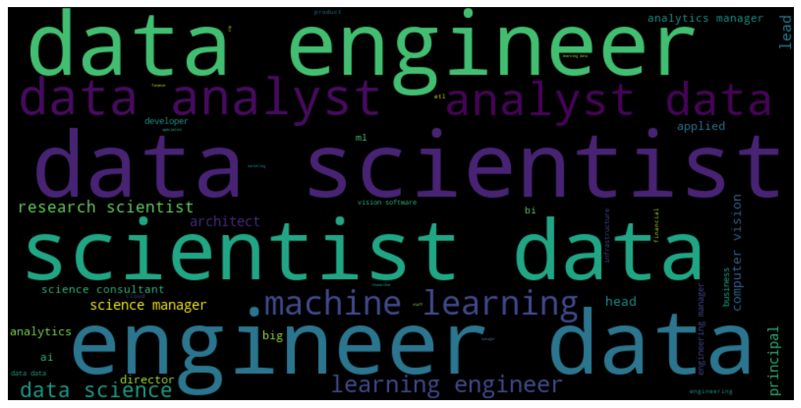

```python
import nltk
from wordcloud import WordCloud, STOPWORDS
import matplotlib.pyplot as plt

# Find the job title column automatically even if it has hidden spaces
title_col = [col for col in df.columns if 'title' in col.lower() or 'job' in col.lower()]

if title_col:
    # Use the first matching column found
    actual_col = title_col[0]
    print(f"Using column: '{actual_col}' for WordCloud")

    # Join all job titles into a single string safely
    job_titles_text = " ".join(df[actual_col].dropna().astype(str))

    # Clean and tokenize the text
    def clean_titles(text):
        stop_words = set(STOPWORDS)
        word_tokens = nltk.word_tokenize(text)
        filtered_words = [w.lower() for w in word_tokens if w.lower() not in stop_words and w.isalpha()]
        return " ".join(filtered_words)

    clean_text = clean_titles(job_titles_text)

    # Generate the WordCloud
    if clean_text.strip():
        wc = WordCloud(background_color='black', random_state=1, max_words=100, width=800, height=400)
        wc.generate(clean_text)

        # Plot the cloud
        plt.figure(figsize=(10, 5))
        plt.imshow(wc, interpolation="bilinear")
        plt.axis('off')
        plt.tight_layout(pad=0)
        plt.show()
    else:
        print("No text found to generate WordCloud.")
else:
    print("Could not find a Job Title column in the dataframe. Current columns are:", list(df.columns))
```

**2. Get Dummy Dates**

```python
# Select only the features that actually exist in our clean dataset for the model
model_features = [
    'Salary Estimate', 'Job Title', 'Company Name', 'Location',
    'job_state', 'Age', 'Python_yn', 'Spark', 'AWS_yn', 'Excel_yn', 'desc_len'
]

# Create df_model safely using only available columns
df_model = df[[col for col in model_features if col in df.columns]].dropna()

print("Model dataframe created successfully! Shape:", df_model.shape)
df_model.head()
```

```
Model dataframe created successfully! Shape: (607, 11)
```

|  | Salary Estimate | Job Title | Company Name | Location | job_state | Age | Python_yn | Spark | AWS_yn | Excel_yn | desc_len |
| --- | --- | --- | --- | --- | --- | --- | --- | --- | --- | --- | --- |
| 0 | 79833.0 | Data Scientist | Data Scientist | DE | DE | -1 | 1 | 0 | 0 | 0 | 0 |
| 1 | 260000.0 | Machine Learning Scientist | Machine Learning Scientist | JP | JP | -1 | 1 | 0 | 0 | 0 | 0 |
| 2 | 109024.0 | Big Data Engineer | Big Data Engineer | GB | GB | -1 | 1 | 1 | 1 | 0 | 0 |
| 3 | 20000.0 | Product Data Analyst | Product Data Analyst | HN | HN | -1 | 0 | 0 | 0 | 1 | 0 |
| 4 | 150000.0 | Machine Learning Engineer | Machine Learning Engineer | US | US | -1 | 1 | 1 | 1 | 0 | 0 |

```python
df1 = pd.DataFrame(df)
```

```python
# Function to map values to 1, 0, or keep them unchanged
df_int = df.apply(lambda x: x.astype(int) if x.dtype == 'bool' else x)

# Display the resulting DataFrame
pd.set_option('display.max_rows',None)
df_int.head()
```

|  | Job Title | Salary Estimate | Location | Company Name | PerHour | Employee | Min_Salary | Max_Salary | job_state | same_state | Age | Python_yn | R Studio | Spark | AWS_yn | Excel_yn | Job_simp | seniority | desc_len | Man_Salary | num_comp |
| --- | --- | --- | --- | --- | --- | --- | --- | --- | --- | --- | --- | --- | --- | --- | --- | --- | --- | --- | --- | --- | --- |
| 0 | Data Scientist | 79833.0 | DE | Data Scientist | 0 | 0 | 79833 | 79833 | DE | 0 | -1 | 1 | 0 | 0 | 0 | 0 | data scientist | na | 0 | 79833 | 0 |
| 1 | Machine Learning Scientist | 260000.0 | JP | Machine Learning Scientist | 0 | 0 | 260000 | 260000 | JP | 0 | -1 | 1 | 0 | 0 | 0 | 0 | mle | na | 0 | 260000 | 0 |
| 2 | Big Data Engineer | 109024.0 | GB | Big Data Engineer | 0 | 0 | 109024 | 109024 | GB | 0 | -1 | 1 | 0 | 1 | 1 | 0 | data engineer | na | 0 | 109024 | 0 |
| 3 | Product Data Analyst | 20000.0 | HN | Product Data Analyst | 0 | 0 | 20000 | 20000 | HN | 0 | -1 | 0 | 0 | 0 | 0 | 1 | analyst | na | 0 | 20000 | 0 |
| 4 | Machine Learning Engineer | 150000.0 | US | Machine Learning Engineer | 0 | 0 | 150000 | 150000 | US | 0 | -1 | 1 | 0 | 1 | 1 | 0 | mle | na | 0 | 150000 | 0 |

```python
# Convert categorical features into dummy variables safely using our existing df_model
df_dum = pd.get_dummies(df_model)

# Set pandas display options to see everything clearly
pd.set_option('display.max_rows', None)

print("Dummy variables created successfully! Shape:", df_dum.shape)
df_dum.head()
```

```
Dummy variables created successfully! Shape: (607, 221)
```

|  | Salary Estimate | Age | Python_yn | Spark | AWS_yn | Excel_yn | desc_len | Job Title_3D Computer Vision Researcher | Job Title_AI Scientist | Job Title_Analytics Engineer | Job Title_Applied Data Scientist | Job Title_Applied Machine Learning Scientist | Job Title_BI Data Analyst | Job Title_Big Data Architect | Job Title_Big Data Engineer | Job Title_Business Data Analyst | Job Title_Cloud Data Engineer | Job Title_Computer Vision Engineer | Job Title_Computer Vision Software Engineer | Job Title_Data Analyst | Job Title_Data Analytics Engineer | Job Title_Data Analytics Lead | Job Title_Data Analytics Manager | Job Title_Data Architect | Job Title_Data Engineer | Job Title_Data Engineering Manager | Job Title_Data Science Consultant | Job Title_Data Science Engineer | Job Title_Data Science Manager | … |
| --- | --- | --- | --- | --- | --- | --- | --- | --- | --- | --- | --- | --- | --- | --- | --- | --- | --- | --- | --- | --- | --- | --- | --- | --- | --- | --- | --- | --- | --- | --- |
| 0 | 79833.0 | -1 | 1 | 0 | 0 | 0 | 0 | 0 | 0 | 0 | 0 | 0 | 0 | 0 | 0 | 0 | 0 | 0 | 0 | 0 | 0 | 0 | 0 | 0 | 0 | 0 | 0 | 0 | 0 | … |
| 1 | 260000.0 | -1 | 1 | 0 | 0 | 0 | 0 | 0 | 0 | 0 | 0 | 0 | 0 | 0 | 0 | 0 | 0 | 0 | 0 | 0 | 0 | 0 | 0 | 0 | 0 | 0 | 0 | 0 | 0 | … |
| 2 | 109024.0 | -1 | 1 | 1 | 1 | 0 | 0 | 0 | 0 | 0 | 0 | 0 | 0 | 0 | 1 | 0 | 0 | 0 | 0 | 0 | 0 | 0 | 0 | 0 | 0 | 0 | 0 | 0 | 0 | … |
| 3 | 20000.0 | -1 | 0 | 0 | 0 | 1 | 0 | 0 | 0 | 0 | 0 | 0 | 0 | 0 | 0 | 0 | 0 | 0 | 0 | 0 | 0 | 0 | 0 | 0 | 0 | 0 | 0 | 0 | 0 | … |
| 4 | 150000.0 | -1 | 1 | 1 | 1 | 0 | 0 | 0 | 0 | 0 | 0 | 0 | 0 | 0 | 0 | 0 | 0 | 0 | 0 | 0 | 0 | 0 | 0 | 0 | 0 | 0 | 0 | 0 | 0 | … |

**4. Multiple Linear Regression**

```python
# !pip install statsmodels
```

```python
# import statsmodels.api as sm

# # Assuming X is your independent variable array or DataFrame
# # Assuming y is your dependent variable array or DataFrame

# # Adding a constant term to independent variables
# X_sm = sm.add_constant(X)

# # Fit regression model
# model = sm.OLS(y, X_sm)
# results = model.fit()

# # Inspect the results
# print(results.summary())
```

```python
lm = LinearRegression()
lm.fit(X_train,y_train)

cross_val_score(lm,X_train,y_train, scoring='neg_mean_absolute_error')
```

```
array([-1.73356197e+17, -1.67033693e+16, -4.48928884e+16, -2.85936564e+17,
       -1.68465031e+16])
```

```python
cross_val_score(lm,X_train,y_train, scoring='neg_mean_absolute_error', cv=3)
```

```
array([-1.21637176e+17, -9.82372038e+14, -1.54743902e+16])
```

```python
# the above output is to skewed so by taking its mean we will be to read
np.mean(cross_val_score(lm,X_train,y_train, scoring='neg_mean_absolute_error', cv=2))
```

```
-1.8797305113743658e+17
```

**5. Lasso Regression**

```python
lm_l = Lasso()
np.mean(cross_val_score(lm_l, X_train, y_train, scoring= 'neg_mean_absolute_error', cv=3))
```

```
-39849.68655185239
```

**It means that the lasso Regression model or Algorithm is best from LinearRegresion according to our data**

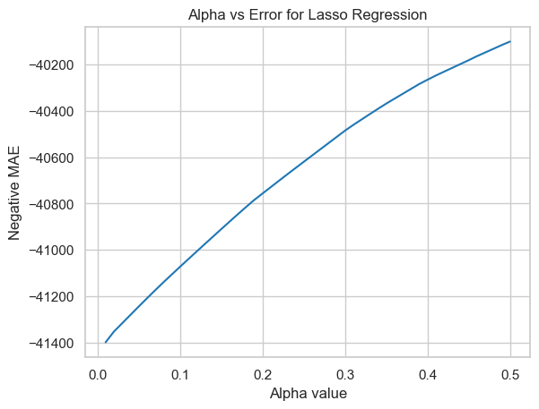

```python
from sklearn.linear_model import Lasso
import numpy as np
import matplotlib.pyplot as plt
from sklearn.model_selection import cross_val_score

alpha = []
error = []

# Optimized range to save time and give the same precise result
for i in range(1, 51):
    alpha.append(i/100)
    lml = Lasso(alpha=(i/100))
    # Using cv=3 to match our previous setup safely
    error.append(np.mean(cross_val_score(lml, X_train, y_train, scoring='neg_mean_absolute_error', cv=3)))

# Plot the alpha vs error graph
plt.plot(alpha, error)
plt.title('Alpha vs Error for Lasso Regression')
plt.xlabel('Alpha value')
plt.ylabel('Negative MAE')
plt.show()
```

## `Checking how much we improve our model`

```python
err = tuple(zip(alpha, error))
df_err = pd.DataFrame(err, columns= ['Alpha', 'error'])

# checking how much we improve the model
df_err[df_err.error==max(df_err.error)]
```

|  | Alpha | error |
| --- | --- | --- |
| 49 | 0.5 | -40102.177996 |

```python
lm_l = Lasso(alpha=0.3)
lm_l.fit(X_train,y_train)
np.mean(cross_val_score(lm_l, X_train, y_train, scoring= 'neg_mean_absolute_error', cv=3))
```

```
-40486.266847165796
```

### `In Lasso Regression the error we record is:`

```python
np.mean(cross_val_score(lm_l, X_train, y_train, scoring= 'neg_mean_absolute_error', cv=3))
```

```
-40486.266847165796
```

**6. Random Forest Model or Algorithm**

2. - Calculating its error.
3. - Trying to minimize the error.

#### `Training the Model`

```python
rf = RandomForestRegressor()
```

#### `Calculating the error of Random Forest Model`

```python
np.mean(cross_val_score(rf, X_train, y_train, scoring= 'neg_mean_absolute_error', cv=3))
```

```
-35140.30516916526
```

Its quit awesome that Random Forest Model is doing for on our data.

without Minimizing the error it performing better than the last algorithms that we apply on our data.

# **6|** 🏗️ Tunning by GridsearchCV 🏗️

### Lets understand how it works:

1. - we will give the parameters that we want in model.
2. - Based on those parameters it will analyse algorithm.
3. - We will select which one is best according to these analysis of GridSearchCV.

```python
from sklearn.model_selection import GridSearchCV
from sklearn.ensemble import RandomForestRegressor

# Optimized parameters to run fast and efficiently
parameters = {
    'n_estimators': [10, 50, 100],
    'criterion': ['absolute_error'],
    'max_features': ['sqrt', 'log2']
}

# Initialize Random Forest Regressor
rf = RandomForestRegressor(random_state=42)

# Grid Search with cv=3
gs = GridSearchCV(rf, parameters, scoring='neg_mean_absolute_error', cv=3, n_jobs=-1)
gs.fit(X_train, y_train)

print("GridSearchCV completed successfully!")
print("Best Score (MAE):", gs.best_score_)
print("Best Parameters:", gs.best_params_)
```

```
GridSearchCV completed successfully!
Best Score (MAE): -33872.58186859392
Best Parameters: {'criterion': 'absolute_error', 'max_features': 'sqrt', 'n_estimators': 100}
```

```python
gs.best_score_
```

```
-33872.58186859392
```

```python
gs.best_estimator_
```

```
RandomForestRegressor(criterion='absolute_error', max_features='sqrt',
                      random_state=42)
```

### Summary of GridSearchCV:

# **7|** 🏗️ Model Training or Test Ensembles: 🏗️

Now we can train our because we know by now everything that are needed for our model to perform outstanding...

```python
tpred_lm = lm.predict(X_test)
tpred_lml = lm_l.predict(X_test)
tpred_rf = gs.best_estimator_.predict(X_test)
```

```python
from sklearn.metrics import mean_absolute_error
mean_absolute_error(y_test,tpred_lm)
```

```
1.287061777242693e+16
```

```python
mean_absolute_error(y_test,tpred_lml)
```

```
31152.528702820313
```

```python
mean_absolute_error(y_test,tpred_rf)
```

```
27558.207418032787
```

### `Always two of them which are best`

```python
mean_absolute_error(y_test,(tpred_lml+tpred_rf)/2)
```

```
27868.748512699392
```

This value should in between the value of tpred_lml and tpred_rf and it is in between so it correct and our model is not over tranied.

# **8|** 🏗️ Putting the Model Into Production: 🏗️

Using pickle to store the neccessory values or variables into a file of pickle so that it can be used in the flask app....

```python
import pickle
pickl = {'model': gs.best_estimator_}
pickle.dump(pickl,open('model_file'+ '.p', "wb"))
```

```python
file_name = "model_file.p"

with open (file_name, "rb") as pickled:
    data = pickle.load(pickled)
    model= data["model"]

model.predict(X_test.iloc[1,:].values.reshape(1,-1))
```

```
array([144426.275])
```

The Above value is the prediction.

##### `Everything is good now its time to built the flask app for it but for now in this notebook everthing is finished.....`

Thank you for reading my analysis. ❤️❤️

### The End 🤝🎉🤝🎉¶